# Neural Computation Group 7 Coursework

This document is split into 3 primary sections:

1. Code

   > The complete code base for this project. Only a brief summary of the classes used is provided here.
2. Code Explanation

   > The explanation as to how and where "Training", "Validation" and "Inference" are carried out. This section will highlight where each of the key features of the associated sub-section can be found within the code as well as a brief overview of it's function. In most cases a more in-depth summary can be found in the report, however one will be provided in this section if there is not one in the report.
3. Report

   > This is the main report. Here we provide an overview of the approaches and experimentations that we undertook during this assignment and provide graphs and formulae that relate to these methods.

## Code

This section provides the full code used within this project. This is so that it can be run within this notebook if desired. This codebase was originally separated into separate files for related classes but this is not possible in Jupyter Notebooks. The original codebase can be viewed at: https://github.com/raghuveerbhat/neuralcomputationUoB. For explanation about this code see the "Code Explanation" or "Report" section(s).

### Imports

```python
import matplotlib.pyplot as plt
from torch.utils.data import DataLoader
import torch.optim as optim
import os
import glob
import cv2
import numpy as np
from torch.utils.data import Dataset
import torch
import torch.nn as nn
import torch.nn.functional as F
import torchvision.models as models
```

### UNet class

Below is our implementation of a Convolutional Neural Network based UNet architecture.

```python
'''Description: Described in https://arxiv.org/abs/1505.04597 '''
class Unet(torch.nn.Module):
    def __init__(self, image_channels, hidden_size=16, n_classes=4):
        '''
          Description:
              Constructor for the Unet class to intialize the parameters for performing Encoding, Bottleneck and Decoding operations.
          Args:
              image_channels  - No of channels in the input image. For our task since we deal with grayscale images no of channel should be 1
              hidden_size     - Represents the no of filters to perform convolution for the subsequent layers
              n_classes       - Represents the number of classes to classified. This will be defined in the problem statement
          Returns:
              Returns the object of the Unet network architecture.
        '''
        super(Unet, self).__init__()
        self.device = torch.device("cuda" if torch.cuda.is_available() else "cpu")

        # Encoder
        self.conv1_1 = nn.Conv2d(in_channels=image_channels, out_channels=hidden_size, kernel_size=3, stride=1,
                                 padding=1)
        self.batch1_1 = nn.BatchNorm2d(hidden_size, affine=True)
        self.conv1_2 = nn.Conv2d(in_channels=hidden_size, out_channels=hidden_size, kernel_size=3, stride=1, padding=1)
        self.batch1_2 = nn.BatchNorm2d(hidden_size, affine=True)
        self.pool1 = nn.MaxPool2d(3, 2, padding=1)
        self.dropout1 = nn.Dropout(0.2)

        self.conv2_1 = nn.Conv2d(in_channels=hidden_size, out_channels=hidden_size * 2, kernel_size=3, stride=1,
                                 padding=1)
        self.batch2_1 = nn.BatchNorm2d(hidden_size * 2, affine=True)
        self.conv2_2 = nn.Conv2d(in_channels=hidden_size * 2, out_channels=hidden_size * 2, kernel_size=3, stride=1,
                                 padding=1)
        self.batch2_2 = nn.BatchNorm2d(hidden_size * 2, affine=True)
        self.pool2 = nn.MaxPool2d(3, 2, padding=1)
        self.dropout2 = nn.Dropout(0.2)

        self.conv3_1 = nn.Conv2d(in_channels=hidden_size * 2, out_channels=hidden_size * 4, kernel_size=3, stride=1,
                                 padding=1)
        self.batch3_1 = nn.BatchNorm2d(hidden_size * 4, affine=True)
        self.conv3_2 = nn.Conv2d(in_channels=hidden_size * 4, out_channels=hidden_size * 4, kernel_size=3, stride=1,
                                 padding=1)
        self.batch3_2 = nn.BatchNorm2d(hidden_size * 4, affine=True)
        self.pool3 = nn.MaxPool2d(3, 2, padding=1)
        self.dropout3 = nn.Dropout(0.2)

        # Bottleneck
        self.bottleneck_conv = nn.Conv2d(in_channels=hidden_size * 4, out_channels=hidden_size * 8, kernel_size=3,
                                         stride=1, padding=1)
        self.bottleneck_batch = nn.BatchNorm2d(hidden_size * 8, affine=True)

        # Decoder
        self.upsample_3 = nn.ConvTranspose2d(in_channels=hidden_size * 8, out_channels=hidden_size * 4, kernel_size=2,
                                             stride=2)
        self.upconv3_1 = nn.Conv2d(in_channels=hidden_size * 8, out_channels=hidden_size * 4, kernel_size=3, stride=1,
                                   padding=1)
        self.upbatch3_1 = nn.BatchNorm2d(hidden_size * 4, affine=True)
        self.upconv3_2 = nn.Conv2d(in_channels=hidden_size * 4, out_channels=hidden_size * 4, kernel_size=3, stride=1,
                                   padding=1)
        self.upbatch3_2 = nn.BatchNorm2d(hidden_size * 4, affine=True)
        self.dropout4 = nn.Dropout(0.2)

        self.upsample_2 = nn.ConvTranspose2d(in_channels=hidden_size * 4, out_channels=hidden_size * 2, kernel_size=2,
                                             stride=2)
        self.upconv2_1 = nn.Conv2d(in_channels=hidden_size * 4, out_channels=hidden_size * 2, kernel_size=3, stride=1,
                                   padding=1)
        self.upbatch2_1 = nn.BatchNorm2d(hidden_size * 2, affine=True)
        self.upconv2_2 = nn.Conv2d(in_channels=hidden_size * 2, out_channels=hidden_size * 2, kernel_size=3, stride=1,
                                   padding=1)
        self.upbatch2_2 = nn.BatchNorm2d(hidden_size * 2, affine=True)
        self.dropout5 = nn.Dropout(0.2)

        self.upsample_1 = nn.ConvTranspose2d(in_channels=hidden_size * 2, out_channels=hidden_size, kernel_size=2,
                                             stride=2)
        self.upconv1_1 = nn.Conv2d(in_channels=hidden_size * 2, out_channels=hidden_size, kernel_size=3, stride=1,
                                   padding=1)
        self.upbatch1_1 = nn.BatchNorm2d(hidden_size, affine=True)
        self.upconv1_2 = nn.Conv2d(in_channels=hidden_size, out_channels=hidden_size, kernel_size=3, stride=1,
                                   padding=1)
        self.upbatch1_2 = nn.BatchNorm2d(hidden_size, affine=True)
        self.dropout6 = nn.Dropout(0.2)

        # Final Layer
        self.conv_out = nn.Conv2d(in_channels=hidden_size, out_channels=n_classes, kernel_size=1, stride=1, padding=0)

    def forward(self, x):
        '''
          Description:
              This method is responsible for the forward propogation. Data will be processed in three stages: Encoder(Downsampling),
              Bottleneck(Effective compression of data) and Decoder(Upsampling).
          Args:
              x  - Image data in the torch.Tensor format with dimension [batch_size, channel, width, height].
          Returns:
              Returns predicted mask in the torch.Tensor format with dimension [batch_size, channel, width, height].
              Here each channel corresponds to each of the 4 classes
        '''
        self.enc_layer1 = F.leaky_relu(self.batch1_1(self.conv1_1(x)))
        self.enc_layer1 = F.leaky_relu(self.batch1_2(self.conv1_2(self.enc_layer1)))
        self.enc_layer1_pool = self.dropout1(self.pool1(self.enc_layer1))

        self.enc_layer2 = F.leaky_relu(self.batch2_1(self.conv2_1(self.enc_layer1_pool)))
        self.enc_layer2 = F.leaky_relu(self.batch2_2(self.conv2_2(self.enc_layer2)))
        self.enc_layer2_pool = self.dropout2(self.pool2(self.enc_layer2))

        self.enc_layer3 = F.leaky_relu(self.batch3_1(self.conv3_1(self.enc_layer2_pool)))
        self.enc_layer3 = F.leaky_relu(self.batch3_2(self.conv3_2(self.enc_layer3)))
        self.enc_layer3_pool = self.dropout3(self.pool3(self.enc_layer3))

        self.bottleneck_layer = F.leaky_relu(self.bottleneck_batch(self.bottleneck_conv(self.enc_layer3_pool)))

        self.up3 = torch.cat((self.upsample_3(self.bottleneck_layer), self.enc_layer3), 1)
        self.up3 = F.leaky_relu(self.batch3_1(self.upconv3_1(self.up3)))
        self.up3 = self.dropout4(F.leaky_relu(self.batch3_2(self.upconv3_2(self.up3))))

        self.up2 = torch.cat((self.upsample_2(self.up3), self.enc_layer2), 1)
        self.up2 = F.leaky_relu(self.batch2_1(self.upconv2_1(self.up2)))
        self.up2 = self.dropout5(F.leaky_relu(self.batch2_2(self.upconv2_2(self.up2))))

        self.up1 = torch.cat((self.upsample_1(self.up2), self.enc_layer1), 1)
        self.up1 = F.leaky_relu(self.batch1_1(self.upconv1_1(self.up1)))
        self.up1 = self.dropout6(F.leaky_relu(self.batch1_2(self.upconv1_2(self.up1))))

        self.out = self.conv_out(self.up1)

        return self.out
```

### DeepLabV3 class and associated classes

Below is our implementation of a DeepLabV3 architecture by referencing https://arxiv.org/abs/1706.05587 and http://www.fregu856.com/project/deeplabv3/. The "Block", "ResNet18" and "ASPP" classes are required by the "DeepLabV3" class.

```python
'''Description: Implemeneted by referencing https://arxiv.org/abs/1706.05587 and http://www.fregu856.com/project/deeplabv3/ '''
'''Requires Resnet18 pretrained model'''
class Block(torch.nn.Module):
    def __init__(self, in_channels, channels, dilation=1):
        '''
          Description:
              Constructor for the Block class.
          Args:
              in_channels     - No of channels
              channels        - No of out channels
              dilation        - Dialtion rate to indicate the how much the kernel is widened.
          Returns:
              Returns the the Block object which can be used on top of Resnet pretrained model.
        '''
        super(Block, self).__init__()

        out_channels = channels

        self.conv1 = nn.Conv2d(in_channels, channels, kernel_size=3, stride=1, padding=dilation, dilation=dilation,
                               bias=False)
        self.batch1 = nn.BatchNorm2d(channels)

        self.conv2 = nn.Conv2d(channels, channels, kernel_size=3, stride=1, padding=dilation, dilation=dilation,
                               bias=False)
        self.batch2 = nn.BatchNorm2d(channels)

        if in_channels != channels:
            conv = nn.Conv2d(in_channels, channels, kernel_size=1, stride=1, bias=False)
            batch = nn.BatchNorm2d(channels)
            self.downsample = nn.Sequential(conv, batch)
        else:
            self.downsample = nn.Sequential()

    def forward(self, x):
        out = F.relu(self.batch1(self.conv1(x)))
        out = self.batch2(self.conv2(out))
        out = out + self.downsample(x)
        out = F.relu(out)
        return out


class ResNet18(torch.nn.Module):
    def __init__(self):
        '''
          Description:
              We are using pretrained Resnet18 as the backbone for our DeepLabV3 implementation.
        '''
        super(ResNet18, self).__init__()
        # Use ResNet18
        resnet = models.resnet18()  # 18 convolution layers
        # load pretrained model
        resnet.load_state_dict(torch.load("./ResnetModels/resnet18-f37072fd.pth"))
        # remove fully connected layer, avg pool, layer4 and layer5
        self.resnet = nn.Sequential(*list(resnet.children())[:-4])

        blocks = []
        blocks.append(Block(in_channels=128, channels=256, dilation=2))
        blocks.append(Block(in_channels=256, channels=256, dilation=2))
        self.layer4 = nn.Sequential(*blocks)
        blocks = []
        blocks.append(Block(in_channels=256, channels=512, dilation=4))
        blocks.append(Block(in_channels=512, channels=512, dilation=4))
        self.layer5 = nn.Sequential(*blocks)

    def forward(self, x):
        out = self.resnet(x)
        out = self.layer4(out)
        out = self.layer5(out)
        return out


class ASPP(torch.nn.Module):
    def __init__(self, num_classes, in_scale=1):
        '''
          Description:
              Atrous Spatial Pyramid Pooling implementation. This module is used in
              resampling a given feature layer at multiple rates prior to convolution.
        '''
        super(ASPP, self).__init__()

        self.conv1_1 = nn.Conv2d(in_scale * 512, 256, kernel_size=1)
        self.batch1_1 = nn.BatchNorm2d(256)
        self.conv1_2 = nn.Conv2d(in_scale * 512, 256, kernel_size=3, stride=1, padding=6, dilation=6)
        self.batch1_2 = nn.BatchNorm2d(256)
        self.conv1_3 = nn.Conv2d(in_scale * 512, 256, kernel_size=3, stride=1, padding=12, dilation=12)
        self.batch1_3 = nn.BatchNorm2d(256)
        self.conv1_4 = nn.Conv2d(in_scale * 512, 256, kernel_size=3, stride=1, padding=18, dilation=18)
        self.batch1_4 = nn.BatchNorm2d(256)

        self.pool = nn.AdaptiveAvgPool2d(1)

        self.conv2 = nn.Conv2d(in_scale * 512, 256, kernel_size=1)
        self.batch2 = nn.BatchNorm2d(256)

        self.conv3 = nn.Conv2d(1280, 256, kernel_size=1)
        self.batch3 = nn.BatchNorm2d(256)

        self.conv4 = nn.Conv2d(256, num_classes, kernel_size=1)

    def forward(self, x):
        # get the height and width of feature map for upsampling
        h = x.size()[2]
        w = x.size()[3]

        out1 = F.leaky_relu(self.batch1_1(self.conv1_1(x)))
        out2 = F.leaky_relu(self.batch1_2(self.conv1_2(x)))
        out3 = F.leaky_relu(self.batch1_3(self.conv1_3(x)))
        out4 = F.leaky_relu(self.batch1_4(self.conv1_4(x)))

        out = self.pool(x)
        out = F.leaky_relu(self.batch2(self.conv2(out)))

        # Upsampling step
        out_img = F.interpolate(out, size=(h, w), mode="bilinear", align_corners=True)
        out = torch.cat([out1, out2, out3, out4, out_img], 1)
        out = F.leaky_relu(self.batch3(self.conv3(out)))
        out = self.conv4(out)

        return out


class DeepLabV3(torch.nn.Module):
    def __init__(self, n_classes=4):
        '''
          Description:
              DeepLabV3 implementation which uses Renet18 pretrained model as backbone along with
              ASPP module.
        '''
        super(DeepLabV3, self).__init__()

        # Load resnet model
        # Pretrained for 18 Convolution layers
        self.resnet = ResNet18()
        # Load ASPP model
        self.aspp = ASPP(num_classes=n_classes, in_scale=1)

    def forward(self, x):
        # get the height and width of feature map for upsampling
        h = x.size()[2]
        w = x.size()[3]

        feature_map = self.resnet(x)
        out = self.aspp(feature_map)
        # Upsampling step
        out = F.interpolate(out, size=(h, w), mode="bilinear", align_corners=True)
        return out
```

### DatasetClass class

Below is the DatasetClass class that we used to manage the loading in of training/evaluation data. Here light data augmentation techniques like horizontal and vertical flipping is carried out, as well as random rotation between -10 to 10 degrees.

```python
class DatasetClass(Dataset):
    def __init__(self, root='', flag='train', aug=True):
        super(DatasetClass, self).__init__()
        self.flag = flag  # Check whether class is used for training, val or test
        self.aug = aug  # Flag to perform augmentation
        self.img_files = glob.glob(os.path.join(root, 'image', '*.png'))
        self.mask_files = []
        for img_path in self.img_files:
            basename = os.path.basename(img_path)
            self.mask_files.append(os.path.join(root, 'mask', basename[:-4]+'_mask.png'))

    def __getitem__(self, index):
        img_path = self.img_files[index]
        data = cv2.imread(img_path, cv2.IMREAD_UNCHANGED) # Read input image
        if self.flag == 'test':
            data = np.expand_dims(data, 0)
            data_tensor = torch.from_numpy(data).float()/255 # Normalize pixels to lie between [0, 1]
            return data_tensor
        else:
            mask_path = self.mask_files[index]
            label = cv2.imread(mask_path, cv2.IMREAD_UNCHANGED)
            if self.flag=='train' and self.aug:
                rand_int = np.random.randint(4)
                if rand_int == 0:   # No augmentation
                    pass
                elif rand_int == 1: # Horizontal flip
                    data, label = cv2.flip(data, 1), cv2.flip(label, 1)
                elif rand_int == 2: # Vertical flip
                    data, label = cv2.flip(data, 0), cv2.flip(label, 0)
                else:               # Rotation
                    angle = np.random.randint(-10, 10)
                    w, h = data.shape[1], data.shape[0]
                    M =  cv2.getRotationMatrix2D((w/2, h/2), angle, 1.0)
                    data, label = cv2.warpAffine(data, M, (w,h)), cv2.warpAffine(label, M, (w,h))

            data = np.expand_dims(data, 0)
            # Create tensor and normalize pixels to lie between [0, 1]
            data_tensor, label_tensor = torch.from_numpy(data).float()/255, torch.from_numpy(label).long()
            return data_tensor, label_tensor

    def __len__(self):
        return len(self.img_files)
```

### Loss function classes

Below are various loss function classes that we implemented to allow us to more easily test for which was most effective. A more detailed explanation of each loss can be found in the report section

```python
class FocalLoss(nn.Module):
    def __init__(self, weights, alpha=0.9, gamma=2, beta=0.9):
        super(FocalLoss, self).__init__()
        self.alpha = alpha  # weight parameter for class imbalance
        self.gamma = gamma  # weight parameter for hard/easy examples
        self.device = torch.device("cuda" if torch.cuda.is_available() else "cpu")
        self.betas = torch.ones((weights.shape[0])) * beta
        self.weights = (1 - self.betas) / (1 - self.betas ** torch.from_numpy(weights))
        self.CEloss = nn.CrossEntropyLoss(self.weights.float().to(self.device)).to(self.device)

    def forward(self, preds, targets):
        ce_loss = self.CEloss(preds, targets) # Cross entropy loss
        pt = torch.exp(-ce_loss)              # Calculation of weight to penalize tough examples
        focal_loss = (self.alpha * (1 - pt) ** self.gamma * ce_loss).mean() # loss calculation
        return focal_loss


class DiceLoss(nn.Module):
    def __init__(self):
        super(DiceLoss, self).__init__()

    def forward(self, preds, targets):
        preds = F.softmax(preds, 1)
        targets = F.one_hot(targets).permute(0, 3, 1, 2)
        # dice score is calculated as (2*IOU)/ (sum of individual areas)
        dice_loss = 2 * torch.sum(preds * targets, axis=[2, 3]) / (
                    torch.sum(preds, axis=[2, 3]) + torch.sum(targets, axis=[2, 3]))
        return 1 - dice_loss.mean() # soft dice loss


class DiceFocalLoss(nn.Module):
    def __init__(self, alpha=0.9, gamma=2):
        super(DiceFocalLoss, self).__init__()
        self.alpha = alpha
        self.gamma = gamma
        self.CEloss = nn.CrossEntropyLoss()

    def forward(self, preds, targets):
        # focal loss
        ce_loss = self.CEloss(preds, targets)
        pt = torch.exp(-ce_loss)
        focal_loss = (self.alpha * (1 - pt) ** self.gamma * ce_loss).mean()

        # dice loss
        preds = F.softmax(preds, 1)
        targets = F.one_hot(targets).permute(0, 3, 1, 2)
        dice_loss = 2 * torch.sum(preds * targets, axis=[2, 3]) / (
                    torch.sum(preds, axis=[2, 3]) + torch.sum(targets, axis=[2, 3]))
        dice_loss = 1 - dice_loss.mean()

        loss = focal_loss + dice_loss # Sum of focal loss and dice loss
        return loss


class CEDiceLoss(nn.Module):
    def __init__(self):
        super(CEDiceLoss, self).__init__()
        self.CEloss = nn.CrossEntropyLoss()

    def forward(self, preds, targets):
        ce_loss = self.CEloss(preds, targets)
        preds = F.softmax(preds, 1)
        targets = F.one_hot(targets).permute(0, 3, 1, 2)
        dice_loss = 2 * torch.sum(preds * targets, axis=[2, 3]) / (
                    torch.sum(preds, axis=[2, 3]) + torch.sum(targets, axis=[2, 3]))
        dice_loss = 1 - dice_loss.mean()
        return ce_loss + dice_loss # Sum of cross entropy and dice loss


class WeightedDiceLoss(nn.Module):
    def __init__(self, weights, beta=0.9):
        super(WeightedDiceLoss, self).__init__()
        self.device = torch.device("cuda" if torch.cuda.is_available() else "cpu")
        self.betas = torch.ones((weights.shape[0])) * beta
        self.weights = (1 - self.betas) / (1 - self.betas ** torch.from_numpy(weights)) # weights obtained from our data analysis
        self.CEloss = nn.CrossEntropyLoss(self.weights.float().to(self.device)).to(self.device)

    def forward(self, preds, targets):
        ce_loss = self.CEloss(preds, targets)
        preds = F.softmax(preds, 1)
        targets = F.one_hot(targets).permute(0, 3, 1, 2)
        dice_loss = 2 * torch.sum(preds * targets, axis=[2, 3]) / (
                    torch.sum(preds, axis=[2, 3]) + torch.sum(targets, axis=[2, 3]))
        dice_loss = 1 - dice_loss.mean()
        return ce_loss + dice_loss # Sum of weighted cross entropy and dice loss
```

### Evaluation Metrics class

This class assisted us in making comparisons between different model implementations and loss functions etc.

```python
class Evaluation_Metrics():
    def __init__(self):
        self.se = nn.MSELoss()
        pass

    def multi_class_dice_score(self, preds, targets):
        "Compute dice score as (2*IOU)/ (sum of individual areas)"
        dice_score = 2 * torch.sum(preds * targets, axis=[2, 3]) / (torch.sum(preds, axis=[2, 3]) + torch.sum(targets, axis=[2, 3]))
        return dice_score.mean(axis=0)

    def accuracy(self, preds, targets):
        """Calculate pixel wise accuracy"""
        pred = F.one_hot(torch.argmax(preds, axis=1)).permute(0, 3, 1, 2)
        acc = (pred==targets).float().mean(axis=[2,3]).mean(axis=0)
        return acc

    def iou(self, preds, targets):
        """Compute intersection over union of 2 masks"""
        intersection = torch.sum(preds * targets, axis=[2, 3])
        total_area = torch.sum(preds, axis=[2, 3]) + torch.sum(targets, axis=[2, 3])
        dice_score = intersection / (total_area - intersection)
        return dice_score.mean(axis=0)

    def evaluate(self, preds, targets):
        """Calculate combined scores for all Dice score, Accuracy and IOU"""
        preds = F.softmax(preds, 1)
        targets = F.one_hot(targets).permute(0, 3, 1, 2)
        dice_score = self.multi_class_dice_score(preds, targets)
        accuracy = self.accuracy(preds, targets)
        iou = self.iou(preds, targets)
        return [dice_score.cpu().numpy(), accuracy.cpu().numpy(), iou.cpu().numpy()]
```

### Main class

This class is the main entry and execution point for the program.

```python
class Main:
    def __init__(self, train=True, test=True, eval=True, train__dir='./data/train', test_dir='./data/test',
                 val_dir="./data/val", epochs=3, learning_rate=1e-3, reg=1e-4, batch_size=16, num_workers=2,
                 load_model_params=True, save_model_params=True, saved_params_path="models/focalloss_earlystop.pt",
                 save_freq=5, dataset_debug=True, loss_fn='Focal', tensorboard_log='runs/test_1',
                 model_arch='DeepLabV3', test_path='test_results', aug=True, early_stop=True, use_tensorboard=False):

        # initialize class properties from arguments
        self.train_dir, self.test_dir = train__dir, test_dir
        self.epochs, self.lr, self.reg = epochs, learning_rate, reg
        self.batch_size, self.num_workers = batch_size, num_workers
        self.val_dir = val_dir
        self.save_model_params = save_model_params
        self.saved_params_path = saved_params_path
        self.save_freq = save_freq
        self.model_arch = model_arch
        self.test_path = test_path
        self.aug = aug
        self.early_stop = early_stop
        self.use_tensorboard=use_tensorboard
        if not os.path.exists(self.test_path):
            os.makedirs(self.test_path)

        # determine if GPU can be used and assign to 'device' class property
        self.device = torch.device("cuda" if torch.cuda.is_available() else "cpu")

        # set properties relating to dataset
        self.train_dataset_size = len(glob.glob(os.path.join(self.train_dir, 'image', "*.png")))
        self.train_dataset = DatasetClass(self.train_dir, flag='train', aug=self.aug)
        self.val_dataset = DatasetClass(self.val_dir, flag='val')
        self.test_dataset = DatasetClass(self.test_dir, flag='test')

        # load data ready for training
        self.train_dataloader = DataLoader(self.train_dataset, self.batch_size, shuffle=True,
                                           num_workers=self.num_workers, pin_memory=True, drop_last=True)
        self.val_dataloader = DataLoader(self.val_dataset, self.batch_size, shuffle=True,
                                         num_workers=1, pin_memory=True, drop_last=False)
        self.test_dataloader = DataLoader(self.test_dataset, self.batch_size, shuffle=False,
                                          num_workers=1, pin_memory=True, drop_last=False)

        # create the model
        if self.model_arch == 'Unet':
            self.model = Unet(image_channels=1, hidden_size=32).to(self.device)
        elif self.model_arch == 'DeepLabV3':
            self.model = DeepLabV3(n_classes=4).to(self.device)

        # load model parameters from file
        if load_model_params and os.path.isfile(saved_params_path):
            self.model.load_state_dict(torch.load(saved_params_path, map_location=self.device))

        # set loss function
        if loss_fn == 'CE':
            self.loss = nn.CrossEntropyLoss()
        elif loss_fn == 'Focal':
            self.loss = FocalLoss(self.dataset_properties())
        elif loss_fn == 'Dice':
            self.loss = DiceLoss()
        elif loss_fn == 'DiceFocal':
            self.loss = DiceFocalLoss(alpha=0.99)
        elif loss_fn == 'CEDice':
            self.loss = CEDiceLoss()
        elif loss_fn == 'WeightedDice':
            self.loss = WeightedDiceLoss(self.dataset_properties())

        # set optimiser
        self.optim = optim.Adam(self.model.parameters(), self.lr, weight_decay=self.reg)

        # evaluation metrics
        self.eval_metrics = Evaluation_Metrics()

        if dataset_debug:
            self.data_viz()  # Visualize the training data alongside it's masks

        if train:
            if self.use_tensorboard:
                from torch.utils.tensorboard import SummaryWriter
                self.writer = SummaryWriter(tensorboard_log)
                print("TENSORBOARD")
            self.train()  # carry out training
            if self.use_tensorboard:
                self.writer.close()

        if test:
            self.model_test()  # Forward pass of model

        if eval:
            self.test_preds_generate()  # Save masks
            self.submission_converter(self.test_path, "")  # Create csv file
            self.evaluate()  # Evaluate dice score

    def dataset_properties(self):
        """Find out statistics about number of pixels in the dataset belonging to each class"""
        class_scores = {}
        mask = None
        for i in range(self.train_dataset_size):
            mask = cv2.imread(os.path.join(self.train_dir, 'mask', 'cmr{}_mask.png'.format(str(i + 1))),
                              cv2.IMREAD_UNCHANGED)
            for idx in np.unique(mask):
                pix_count = np.where(mask == idx)
                if idx not in class_scores.keys():
                    class_scores[idx] = pix_count[0].shape[0]  # Create new keys in dict
                else:
                    class_scores[idx] += pix_count[0].shape[0]  # Update already existing key
        plot_list = []
        if mask is not None:
            for idx in class_scores.keys():
                class_scores[idx] /= (mask.shape[0] * mask.shape[1] * self.train_dataset_size)
                plot_list.append(class_scores[idx] * 100)  # Convert to percentage

        return np.array(plot_list)

    def data_viz(self):
        """Displays each training data image with its corresponding masks"""
        for i in range(self.train_dataset_size):
            image = cv2.imread(os.path.join(self.train_dir, 'image', 'cmr{}.png'.format(str(i + 1))),
                               cv2.IMREAD_UNCHANGED)
            mask = cv2.imread(os.path.join(self.train_dir, 'mask', 'cmr{}_mask.png'.format(str(i + 1))),
                              cv2.IMREAD_UNCHANGED)
            self.dummy_mask = np.zeros((image.shape[0], image.shape[1], len(np.unique(mask))))
            # returns True when visualization should continue
            if self.mask_prepare(image, mask):
                pass
            else:
                break
```

```python
    def mask_prepare(self, img, mask):
        """ Format each features image to be white on the feature and black everywhere else.
			Then combine into one image and display."""
        # filter out all pixels that are not 255 for each feature
        for i in range(len(np.unique(mask))):
            self.dummy_mask[:, :, i][np.where(mask == i)] = 255

        imgs = [img.astype(np.uint8)]
        for i in range(len(np.unique(mask))):
            imgs.append(self.dummy_mask[:, :, i].astype(np.uint8))

        # combine each feature map into one image
        out = np.hstack(imgs)

        # display image
        cv2.imshow("Feature maps", out)

        # quit when q key is pressed
        k = cv2.waitKey()
        if k == ord('q'):
            return False
        return True

    def train(self):
        """Carry out training on the model"""
        train_losses = []
        val_losses = []
        early_stopping_check = None
        check = 0
        patience, best_loss= 5, 0
        self.model.train()
        for epoch in range(self.epochs):
            train_epoch_loss = 0
            val_epoch_loss = 0
            val_scores = []

            # training batch
            for batch_idx1, (data, label) in enumerate(self.train_dataloader):
                data, label = data.to(self.device), label.to(self.device)
                if self.model_arch == 'DeepLabV3':
                    data = data.expand(-1, 3, -1, -1)
                out = self.model(data)  # forward pass
                loss = self.loss(out, label)  # loss calculation
                self.optim.zero_grad()  # back-propogation
                loss.backward()
                self.optim.step()
                train_epoch_loss += loss

            # validation batch, only used for tracking loss reduction over time
            for batch_idx2, (data, label) in enumerate(self.val_dataloader):
                data, label = data.to(self.device), label.to(self.device)
                if self.model_arch == 'DeepLabV3':
                    data = data.expand(-1, 3, -1, -1)
                with torch.no_grad():
                    out = self.model(data)  # forward pas
                    loss = self.loss(out, label)  # val loss calculation
                    val_epoch_loss += loss
                    val_score = self.eval_metrics.evaluate(out, label)
                    val_scores.append(val_score)

            train_epoch_loss = train_epoch_loss.cpu().item() / max(1, batch_idx1)
            val_epoch_loss = val_epoch_loss.cpu().item() / max(1, batch_idx2)
            train_losses.append(train_epoch_loss)
            val_losses.append(val_epoch_loss)
            val_scores = np.mean(np.array(val_scores), axis=0)

            if self.use_tensorboard:
                self.writer.add_scalar("Train Loss", train_epoch_loss, epoch)
                self.writer.add_scalar("Val Loss", val_epoch_loss, epoch)
                self.writer.add_scalars('Mean Scores', {'Dice Score': np.mean(val_scores[0]),
                                                    'Accuracy': np.mean(val_scores[1]),
                                                    'IOU': np.mean(val_scores[2])}, epoch)

                for i in range(val_scores.shape[1]):
                    self.writer.add_scalars('Class{}'.format(str(i)), {'Dice Score': val_scores[0][i],
                                                                   'Accuracy': val_scores[1][i],
                                                                   'IOU': val_scores[2][i]}, epoch)

            print("EPOCH {}: ".format(epoch), train_epoch_loss, val_epoch_loss)

            # save model parameters to file
            if ((epoch + 1) % self.save_freq == 0) and self.save_model_params:
                print("Saving model")
                torch.save(self.model.state_dict(), self.saved_params_path)

            # early stopping
            if self.early_stop:
                if epoch==0:
                    best_loss = np.mean(val_epoch_loss)
                if val_epoch_loss < best_loss:
                    # save model parameters to file
                    print("Saving model")
                    torch.save(self.model.state_dict(), self.saved_params_path)
                    best_loss = val_epoch_loss
                    check = 0
                elif val_epoch_loss >= best_loss:
                    check += 1
                    if check >=patience:
                        print("EARLY STOPPING")
                        break

    def model_test(self):
        """display performance on each of validation data"""
        if self.model_arch == 'DeepLabV3':
            self.model.eval()
        for i in range(1, 21):
            iStr = "0" + str(i) if i < 10 else str(i)

            # load in base image
            img = cv2.imread(os.path.join(self.val_dir, 'image', 'cmr1{}.png'.format(iStr)), cv2.IMREAD_UNCHANGED)

            # load in correct mask
            img_mask = cv2.imread(os.path.join(self.val_dir, 'mask', 'cmr1{}_mask.png'.format(iStr)),
                                  cv2.IMREAD_UNCHANGED)

            # convert base image to tensor and normalize pixels to lie between [0, 1]
            self.img_tensor = torch.from_numpy(np.expand_dims(np.expand_dims(img.astype(np.uint8), 0), 0)).to(
                self.device).float() / 255

            with torch.no_grad():
                # process through model
                if self.model_arch == 'DeepLabV3':
                    self.img_tensor = self.img_tensor.expand(-1, 3, -1, -1)
                out = self.model(self.img_tensor)
                out = F.softmax(out, 1).permute(0, 2, 3, 1)
                out = self.one_hot(out).cpu().numpy()[0] * 255
                # stack processed images into one image
                out_img = np.hstack((img.astype(np.uint8),
                                     out[:, :, 0].astype(np.uint8),  # background
                                     out[:, :, 1].astype(np.uint8),  # right ventricle
                                     out[:, :, 2].astype(np.uint8),  # myocardium
                                     out[:, :, 3].astype(np.uint8)))  # left ventricle
```

```python
                # process mask to produce mirror stacked image as above, with features in the same places
                out_actual = np.zeros((img_mask.shape[0], img_mask.shape[1], len(np.unique(img_mask))))
                for i in range(len(np.unique(img_mask))):
                    out_actual[:, :, i][np.where(img_mask == i)] = 255
                out_actual_img = np.hstack((img.astype(np.uint8),
                                            out_actual[:, :, 0].astype(np.uint8),  # background
                                            out_actual[:, :, 1].astype(np.uint8),  # right ventricle
                                            out_actual[:, :, 2].astype(np.uint8),  # myocardium
                                            out_actual[:, :, 3].astype(np.uint8)))  # left ventricle

                # display both images
                cv2.imshow("MODEL OUTPUT", out_img)
                cv2.imshow("ACTUAL MASK", out_actual_img)
                k = cv2.waitKey()
                if k == ord('q'):
                    exit()

    def test_preds_generate(self):
        """saves and displays performance on each of test data"""
        if self.model_arch == 'DeepLabV3':
            self.model.eval()
        self.test_data = glob.glob(os.path.join(self.test_dir, 'image', "*.png"))
        for i, file in enumerate(self.test_data):
            img = cv2.imread(file, cv2.IMREAD_UNCHANGED)
            self.img_tensor = torch.from_numpy(np.expand_dims(np.expand_dims(img.astype(np.uint8), 0), 0)).to(
                self.device).float()/255
            with torch.no_grad():
                if self.model_arch == 'DeepLabV3':
                    self.img_tensor = self.img_tensor.expand(-1,3,-1,-1)
                out = self.model(self.img_tensor) # forward pass
                out = F.softmax(out, 1).permute(0, 2, 3, 1)
                out_display = out.cpu().numpy()[0]*255
                if i == 0:
                    self.out_mask = np.hstack((img.astype(np.uint8),
                                            out_display[:, :, 0].astype(np.uint8),   # background
                                            out_display[:, :, 1].astype(np.uint8),   # right ventricle
                                            out_display[:, :, 2].astype(np.uint8),   # myocardium
                                            out_display[:, :, 3].astype(np.uint8)))  # left ventricle
                else:
                    self.out_mask = np.vstack((self.out_mask, np.hstack((img.astype(np.uint8),
                                                                out_display[:, :, 0].astype(np.uint8),   # background
                                                                out_display[:, :, 1].astype(np.uint8),   # right ventricle
                                                                out_display[:, :, 2].astype(np.uint8),   # myocardium
                                                                out_display[:, :, 3].astype(np.uint8)))))  # left ventricle

                # display both images
                out = self.un_one_hot(out).cpu().numpy()[0]
                path = self.test_path + "/" + file.split("\\")[-1].split(".")[0] + "_mask.png"
                cv2.imwrite(path, out)

        plt.imshow(self.out_mask.squeeze())
        plt.show()

    def evaluate(self):
        """performance on each of validation data"""
        if self.model_arch == 'DeepLabV3':
            self.model.eval()
        dice_scores = []
        for i in range(1, 21):
            iStr = "0" + str(i) if i < 10 else str(i)

            # load in base image
            img = cv2.imread(os.path.join(self.val_dir, 'image', 'cmr1{}.png'.format(iStr)), cv2.IMREAD_UNCHANGED)

            # load in correct mask
            img_mask = cv2.imread(os.path.join(self.val_dir, 'mask', 'cmr1{}_mask.png'.format(iStr)),
                                  cv2.IMREAD_UNCHANGED)

            # convert base image to tensor
            self.img_tensor = torch.from_numpy(np.expand_dims(np.expand_dims(img.astype(np.uint8), 0), 0)).to(
                self.device).float()
            self.img_mask = torch.from_numpy(np.expand_dims(img_mask.astype(np.uint8), 0)).to(
                self.device).float()
            if self.model_arch == 'DeepLabV3':
                self.img_tensor = self.img_tensor.expand(-1, 3, -1, -1)
            with torch.no_grad():
                # process through model
                out = self.model(self.img_tensor)
                out = F.softmax(out, 1).permute(0, 2, 3, 1)
                out = self.un_one_hot(out)
                dice_scores.append(self.categorical_dice(out.permute(1, 2, 0), self.img_mask.permute(1, 2, 0)))
        dice_scores_norm = np.sum(np.array(dice_scores), axis=0) / len(dice_scores)
        num_classes = dice_scores_norm.shape[0]
        plt.bar(["Class " + str(i) for i in range(num_classes)], dice_scores_norm, width=0.1)
        plt.show()
        print(dice_scores_norm, num_classes)

    def one_hot(self, masks):
        return F.one_hot(torch.argmax(masks, axis=-1))

    def un_one_hot(self, masks):
        """ Convert from K channels to 1 channel containing pixel values corresponding to class index"""
        return torch.argmax(masks, axis=-1)

    def categorical_dice(self, mask1, mask2, label_class=1):
        """
		Dice score of a specified class between two volumes of label masks.
		(classes are encoded but by label class number not one-hot )
		Note: stacks of 2D slices are considered volumes.

		Args:
			mask1: N label masks, numpy array shaped (H, W, N)
			mask2: N label masks, numpy array shaped (H, W, N)
			label_class: the class over which to calculate dice scores

		Returns:
			volume_dice
		"""
        labels = torch.unique(mask2)
        dice_scores = []
        for label_class in labels:
            mask1_pos = (mask1 == label_class)
            mask2_pos = (mask2 == label_class)
            dice = 2 * torch.sum(mask1_pos * mask2_pos) / (torch.sum(mask1_pos) + torch.sum(mask2_pos))
            dice_scores.append(dice.cpu().numpy())
        return dice_scores
```

```python
    def rle_encoding(self, x):
        dots = np.where(x.T.flatten() == 1)[0]
        run_lengths = []
        prev = -2
        for b in dots:
            if (b > prev + 1): run_lengths.extend((b + 1, 0))
            run_lengths[-1] += 1
            prev = b
        return run_lengths

    def submission_converter(self, mask_directory, path_to_save):
        writer = open(os.path.join(path_to_save, "submission.csv"), 'w')
        writer.write('id, encoding\n')

        files = os.listdir(mask_directory)

        for file in files:
            name = file[:-4]
            mask = cv2.imread(os.path.join(mask_directory, file), cv2.IMREAD_UNCHANGED)

            mask1 = (mask == 1)
            mask2 = (mask == 2)
            mask3 = (mask == 3)

            encoded_mask1 = self.rle_encoding(mask1)
            encoded_mask1 = ' '.join(str(e) for e in encoded_mask1)
            encoded_mask2 = self.rle_encoding(mask2)
            encoded_mask2 = ' '.join(str(e) for e in encoded_mask2)
            encoded_mask3 = self.rle_encoding(mask3)
            encoded_mask3 = ' '.join(str(e) for e in encoded_mask3)

            writer.write(name + '1,' + encoded_mask1 + "\n")
            writer.write(name + '2,' + encoded_mask2 + "\n")
            writer.write(name + '3,' + encoded_mask3 + "\n")

        writer.close()
```

### Call Function

Below is the call to the Main class which we used to run our trained model on the test data. The changes to this call to allow for different functionalities (such as training or use of a different model/loss function) are explained in their corresponding sub-section of the "Code Explaination" section.

```
if __name__ == '__main__':
    Main(load_model_params=True, save_model_params=True, saved_params_path="models/unettrainval.pt",
         train=False, test=False, eval=True, epochs = 200, loss_fn='Dice', dataset_debug=False,
        tensorboard_log='runs/unet_aug_lr1e-3_reg1e-3_cedice_test_1', model_arch='Unet',
         test_path='test_results', aug=True, early_stop=False)
```

## Code Explanation

### Training

#### Network Architecture

The network architecture that we eventually used was the *UNet*. This network is defined in the `UNet` class above. The model choice can be changed in the Main class call by setting the `model_arch` argument. The choice of model is then selected within the following section of the Main class __init__ method (lines 41-45):

```
# create the model
        if self.model_arch == 'Unet':
            self.model = Unet(image_channels=1, hidden_size=32).to(self.device)
        elif self.model_arch == 'DeepLabV3':
            self.model = DeepLabV3(n_classes=4).to(self.device)
```

Our reason for this choice is outlined in the Different Model Architectures sub-section within the Experiment section of the Report.

#### Loss Function

The loss function that we eventually used was the *DiceFocalLoss*. This is defined in the `DiceFocalLoss` class above but this has also been copied here for convenience (found under the Loss Functions sub-section):

```
class DiceFocalLoss(nn.Module):
    def __init__(self, alpha=0.9, gamma=2):
        super(DiceFocalLoss, self).__init__()
        self.alpha = alpha
        self.gamma = gamma
        self.CEloss = nn.CrossEntropyLoss()

    def forward(self, preds, targets):
        # focal loss
        ce_loss = self.CEloss(preds, targets)
        pt = torch.exp(-ce_loss)
        focal_loss = (self.alpha * (1 - pt) ** self.gamma * ce_loss).mean()

        # dice loss
        preds = F.softmax(preds, 1)
        targets = F.one_hot(targets).permute(0, 3, 1, 2)
        dice_loss = 2 * torch.sum(preds * targets, axis=[2, 3]) / (
                    torch.sum(preds, axis=[2, 3]) + torch.sum(targets, axis=[2, 3]))
        dice_loss = 1 - dice_loss.mean()

        loss = focal_loss + dice_loss
        return loss
```

The selected loss function can be changed in the Main class call by setting the `loss_fn` argument. This in turn will choose the appropriate loss function in the following section of the Main class __init__ method (lines 51-63):

```
# set loss function
        if loss_fn == 'CE':
            self.loss = nn.CrossEntropyLoss()
        elif loss_fn == 'Focal':
            self.loss = FocalLoss(self.dataset_properties())
        elif loss_fn == 'Dice':
            self.loss = DiceLoss()
        elif loss_fn == 'DiceFocal':
            self.loss = DiceFocalLoss(alpha=0.99)
        elif loss_fn == 'CEDice':
            self.loss = CEDiceLoss()
        elif loss_fn == 'WeightedDice':
            self.loss = WeightedDiceLoss(self.dataset_properties())
```

Our reason for this choice is outlined in the Loss Function sub-section within the Experiment section of the Report.

#### Optimizer

We chose to use the ADAM optimiser to train our model. The optimiser is defined on line 66 of the Main class, within it's __init__ method. This line has been copied here:

```
# set optimiser
        self.optim = optim.Adam(self.model.parameters(), self.lr, weight_decay=self.reg)
```

Our tuning of the parameters for this optimiser is outlined in the Optimizer paramater tuning sub-section within the Experiment section of the Report.

#### Training Processing

```
def train(self):
        """Carry out training on the model"""
        train_losses = []
        val_losses = []
        early_stopping_check = None
        check = 0
        patience, best_loss= 5, 0
        self.model.train()
        for epoch in range(self.epochs):
            train_epoch_loss = 0
            val_epoch_loss = 0
            val_scores = []

            # training batch
            for batch_idx1, (data, label) in enumerate(self.train_dataloader):
                data, label = data.to(self.device), label.to(self.device)
                if self.model_arch == 'DeepLabV3':
                    data = data.expand(-1, 3, -1, -1)
                out = self.model(data)  # forward pass
                loss = self.loss(out, label)  # loss calculation
                self.optim.zero_grad()  # back-propogation
                loss.backward()
                self.optim.step()
                train_epoch_loss += loss

            # validation batch, only used for tracking loss reduction over time
            for batch_idx2, (data, label) in enumerate(self.val_dataloader):
                data, label = data.to(self.device), label.to(self.device)
                if self.model_arch == 'DeepLabV3':
                    data = data.expand(-1, 3, -1, -1)
                with torch.no_grad():
                    out = self.model(data)  # forward pas
                    loss = self.loss(out, label)  # val loss calculation
                    val_epoch_loss += loss
                    val_score = self.eval_metrics.evaluate(out, label)
                    val_scores.append(val_score)

            train_epoch_loss = train_epoch_loss.cpu().item() / max(1, batch_idx1)
            val_epoch_loss = val_epoch_loss.cpu().item() / max(1, batch_idx2)
            train_losses.append(train_epoch_loss)
            val_losses.append(val_epoch_loss)
            val_scores = np.mean(np.array(val_scores), axis=0)

            if self.use_tensorboard:
                self.writer.add_scalar("Train Loss", train_epoch_loss, epoch)
                self.writer.add_scalar("Val Loss", val_epoch_loss, epoch)
                self.writer.add_scalars('Mean Scores', {'Dice Score': np.mean(val_scores[0]),
                                                    'Accuracy': np.mean(val_scores[1]),
                                                    'IOU': np.mean(val_scores[2])}, epoch)

                for i in range(val_scores.shape[1]):
                    self.writer.add_scalars('Class{}'.format(str(i)), {'Dice Score': val_scores[0][i],
                                                                   'Accuracy': val_scores[1][i],
                                                                   'IOU': val_scores[2][i]}, epoch)

            print("EPOCH {}: ".format(epoch), train_epoch_loss, val_epoch_loss)

            # save model parameters to file
            if ((epoch + 1) % self.save_freq == 0) and self.save_model_params:
                print("Saving model")
                torch.save(self.model.state_dict(), self.saved_params_path)

            # early stopping
            if self.early_stop:
                if epoch==0:
                    best_loss = np.mean(val_epoch_loss)
                if val_epoch_loss < best_loss:
                    # save model parameters to file
                    print("Saving model")
                    torch.save(self.model.state_dict(), self.saved_params_path)
                    best_loss = val_epoch_loss
                    check = 0
                elif val_epoch_loss >= best_loss:
                    check += 1
                    if check >=patience:
                        print("EARLY STOPPING")
                        break
```

##### Number of epochs

The number of epochs is by default specified as an argument to the Main constructor. However, this can be reduced if the early_stop flag has been set. This flag controls the early stopping branch of the train method and will terminate the training process early if it determines that the learning process has already converged enough: (lines 211-225)

```
# early stopping
if self.early_stop:
    if epoch==0:
        best_loss = np.mean(val_epoch_loss)
    if val_epoch_loss < best_loss:
        # save model parameters to file
        print("Saving model")
        torch.save(self.model.state_dict(), self.saved_params_path)
        best_loss = val_epoch_loss
        check = 0
    elif val_epoch_loss >= best_loss:
        check += 1
        if check >=patience:
            print("EARLY STOPPING")
            break
```

Further detail on the number of epochs covered is detailed in the Early Stopping sub-section of the Implementation section of the report.

##### Each batch

The core training loop for each batch is as follows (lines 162-172):

```
# training batch
for batch_idx1, (data, label) in enumerate(self.train_dataloader):
    data, label = data.to(self.device), label.to(self.device)
    if self.model_arch == 'DeepLabV3':
        data = data.expand(-1, 3, -1, -1)
    out = self.model(data)  # forward pass
    loss = self.loss(out, label)  # loss calculation
    self.optim.zero_grad()  # back-propogation
    loss.backward()
    self.optim.step()
    train_epoch_loss += loss
```

The model performs the usual forward pass, followed by the loss calculation by the loss function. This is back propogated by the optimizer before setting up the loss function and optimizer ready for the next batch. Further information on how these values were determined is available in the Experiment section of the Report.

##### Data loading

The data for training/validating/testing is loaded into the model between lines 27-39. This uses the DatasetClass to load in the data correctly and which performs any augmentations to the data if it is for training. Further information on augmenting is available in the Data Augmentation sub-section of the Experiment section of the report.

```
# set properties relating to dataset
self.train_dataset_size = len(glob.glob(os.path.join(self.train_dir, 'image', "*.png")))
self.train_dataset = DatasetClass(self.train_dir, flag='train', aug=self.aug)
self.val_dataset = DatasetClass(self.val_dir, flag='val')
self.test_dataset = DatasetClass(self.test_dir, flag='test')

# load data ready for training
self.train_dataloader = DataLoader(self.train_dataset, self.batch_size, shuffle=True,
                                    num_workers=self.num_workers, pin_memory=True, drop_last=True)
self.val_dataloader = DataLoader(self.val_dataset, self.batch_size, shuffle=True,
                                    num_workers=1, pin_memory=True, drop_last=False)
self.test_dataloader = DataLoader(self.test_dataset, self.batch_size, shuffle=False,
                                    num_workers=1, pin_memory=True, drop_last=False)
```

### Validation

The below code snippet represents the validation loop of the training process. For each epoch, the data will be processed by the model in a batch with current weights and loss calculation is done. This is will be used to tune the hyperparameters like learning rate, regulariztion etc. This is detailed in the below report section.

```python
 # validation batch, only used for tracking loss reduction over time
for batch_idx2, (data, label) in enumerate(self.val_dataloader):
    data, label = data.to(self.device), label.to(self.device)
    #If model architecture is deeplabv3 then convert 1 channel to 3 channel as Resnet18 expect input in 3 channel
    if self.model_arch == 'DeepLabV3':
        data = data.expand(-1, 3, -1, -1)
    with torch.no_grad():
        out = self.model(data)  # forward pass
        loss = self.loss(out, label)  # val loss calculation
        val_epoch_loss += loss
        val_score = self.eval_metrics.evaluate(out, label)
        val_scores.append(val_score)
```

### Inference

The function below performs inference on our test data, and saves the masks for evaluation.The results for our models have been submitted on the Kaggle leaderboards under the name Vineeth S Subramanyam

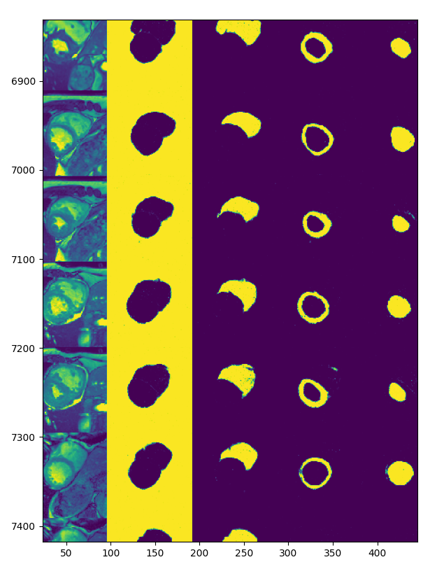

```python
def test_preds_generate(self):
        """saves and displays performance on each of test data"""
        if self.model_arch == 'DeepLabV3':
            self.model.eval()
        self.test_data = glob.glob(os.path.join(self.test_dir, 'image', "*.png"))
        for i, file in enumerate(self.test_data):
            img = cv2.imread(file, cv2.IMREAD_UNCHANGED)
            self.img_tensor = torch.from_numpy(np.expand_dims(np.expand_dims(img.astype(np.uint8), 0), 0)).to(
                self.device).float()/255
            with torch.no_grad():
                if self.model_arch == 'DeepLabV3':
                    self.img_tensor = self.img_tensor.expand(-1,3,-1,-1)
                out = self.model(self.img_tensor) # forward pass
                out = F.softmax(out, 1).permute(0, 2, 3, 1)
                out_display = out.cpu().numpy()[0]*255
                if i == 0:
                    self.out_mask = np.hstack((img.astype(np.uint8),
                                            out_display[:, :, 0].astype(np.uint8),   # background
                                            out_display[:, :, 1].astype(np.uint8),   # right ventricle
                                            out_display[:, :, 2].astype(np.uint8),   # myocardium
                                            out_display[:, :, 3].astype(np.uint8)))  # left ventricle
                else:
                    self.out_mask = np.vstack((self.out_mask, np.hstack((img.astype(np.uint8),
                                                                out_display[:, :, 0].astype(np.uint8),   # background
                                                                out_display[:, :, 1].astype(np.uint8),   # right ventricle
                                                                out_display[:, :, 2].astype(np.uint8),   # myocardium
                                                                out_display[:, :, 3].astype(np.uint8)))))  # left ventricle

                # display both images
                out = self.un_one_hot(out).cpu().numpy()[0]
                path = self.test_path + "/" + file.split("\\")[-1].split(".")[0] + "_mask.png"
                cv2.imwrite(path, out)

        plt.imshow(self.out_mask.squeeze())
        plt.show()
```

# Report

## Introduction

The aim of the project is to train a convolutional neural network for the task of semantic segmentation of Magnetic Resonance Images. Semantic segmentation is the process of assigning pixel wise labels to an image, such that each pixel represents a particular feature/class that we wish to segment. In our work, we train a model to segment the left ventricle, right ventricle and myocardium, with an additional class for background pixels.

The dataset used contains a total of 200 images, which is split into a training set (100 images), a validation set (20 images) and a test set (80 images). The input data is a grayscale image of dimension 96x96, and our label is an encoded mask where each pixel contains the value of the class to which it belongs.

## Implementation

### Model Architecture :

For this task we implemented a Convolutional Neural Network based UNet architecture, which is lightweight and used commonly for medical image segmentation. The model consists of three main blocks; an encoder that progressively downsamples the data in stages, a bottleneck to decrease our data dimensionality, and a decoder block to upsample the encoded feature vector back to the original image dimension.

Each of the three main blocks can be summarised as follows:

- **Encoder:** The encoder downsamples the data in 3 stages, where each stage consists of a set of repeated operations of Convolution + Batch Normalization + Activation, followed by a pooling layer. Each convolution operation uses a 3x3 filter with a stride of 1 and padding of 1. The activation function used is leaky relu since it allows a small negative gradient to flow through our weight update. The pooling layers are followed with a dropout layer (p=0.2) that helps us better generalize our trained weights by reducing overfitting.
- **Bottleneck:** The bottleneck layer consists of a single 3x3 convolution followed by batch normalization and a leaky relu activation. The use of the bottleneck is to constrain the model to learn a more compressed version of our input data.
- **Decoder:** The decoder upsamples the data in 3 stages similar to the encoder, with an added filter concatenation step. At each step, we concatenate the output from the corresponding block of our encoder to allow us to carry forward lower level features from our network. A transposed convolution (kernel size=2, stride=2) is used to perform upsampling since it allows us to perform learnable upsampling of the data. The final layer of the decoder is a convolutional layer with a 1x1 filter size to remap our data to match our desired channel output size of 4

[figure not shown]

*Figure 1 - UNet architecture*

### Optimizer:

We used the Adam optimizer to train our model since it offers an adaptive technique of finding the minima with a lower number of iterations as compared to other techniques like Stochastic Gradient Descent. The optimizer was initialized with a learning rate of 1e-3, and a L2 weight regularization of 1e-4. The weight decay term adds an additional penalty to allow us to minimize our weights and reduce overfitting.

### Loss Function:

[figure not shown]

*Figure 2 - Percentage of each class in the overall dataset*

## Experiment

### Loss Function:

We have experimented with a combination of loss functions listed below, and evaluated their results using the validation metrics obtained.

1. **Cross Entropy:** A simple class wise categorical cross entropy function which performs a pixelwise loss by maximizing the value of the true class. The torch cross entropy function used in the code performs softmax followed by an nll log loss to compute the cross entropy loss.

\begin{align} \mathbf{Loss} = -\sum_{n=1}^N \sum_{m=1}^{\mathbf{num\:classes}} ylog(\hat{y}) + (1-y)log(1-\hat{y}) \end{align}

1. **Weighted Cross Entropy:** The cross entropy loss calculated for each class is weighted by a factor called the effective number of samples. This factor is calculated using the normalized number of pixels in each class. We initialized the weights for each class using the calculated percentages calculated from Figure 2.

\begin{align} \mathbf{weight} = \frac{(1-β)}{(1-β^n)} \end{align}\begin{align} \mathbf{Loss} = -\sum_{n=1}^N \sum_{m=1}^{\mathbf{num\:classes}} \mathbf{weight}*(ylog(\hat{y}) + (1-y)log(1-\hat{y})) \end{align}

1. **Focal loss:** Focal loss is another technique of weighted cross entropy that tries to handle two issues pertaining to class imbalance and classifying difficult examples. The term (1-pt) penalizes the predictions based on difficulty(background pixels are considered to be easy), and the alpha term is used as a weight factor for cross entropy. The value gamma is a modulating factor that is chosen such that >= 0.

\begin{align} \mathbf{Loss} = -α(1-p)^γlog(p) \end{align}

1. **Soft Dice loss:** Soft Dice loss is based on the dice coefficient that is used to measure the amount of overlap between two masks. The dice score is calculated to be twice the intersection, divided by the total area covered by both masks. The score ranges from [0,1], where the dice score of 1 represents the perfect overlap. The loss function is therefore formulated to be 1 - dice score, which constrains the model to learn a mapping that maximizes the intersection of the predicted mask and ground truth.

\begin{align} \mathbf{Loss} = 1-\frac{2*(\mathbf{pred} \cap \mathbf{ground\:truth})}{(\mathbf{pred} + \mathbf{ground\:truth})} \end{align}

We implemented combinations of these loss functions such as Dice-Focal, CE-Dice and Weighted CE Dice loss, and made comparisons in tensorboard for accuracy, IOU and dice score. The comparisons were made using both a mean score over all classes, and individual class performance. The Dice-Focal loss function was chosen since it gave us the best results over both the mean class, and individual class scores.

[figure not shown]

*Figure 3 - Comparison of validation metrics for loss functions*

### Data Augmentation

Data Augmentation is used to account for variations that may be present in our real-world data that may not exist in our training set. Convolutional neural networks require huge amounts of data covering a wide variety of variations to be able to perform accurately at test time. Since our dataset contains only 100 training images, we make use of random data augmentation to help us synthetically increase the size of our training data. This allows the model to better generalize to the task, and helps us to obtain much better results on our validation set. Since heavy augmentation may misrepresent the anatomical structure of the heart[2], we instead use only light data augmentation techniques such as random rotation and flipping of the images. For each training image, 1 of 4 possible combinations is used:

1. **No Augmentation:** No Augmentation is applied to the image.
2. **Horizontal Flip:** The image is flipped horizontally along the y axis.
3. **Vertical Flip:** The image is flipped horizontally along the x axis
4. **Random Rotation:** The image is rotated randomly between an angle of -10 to +10 degrees.

We compared the model’s performance with and without augmentation using our validation metrics(for individual class, and mean score) below, and observed on average an increase in accuracy of around 2-3% depending on the chosen model parameters.

[figure not shown]

*Figure 4 - Comparison of validation metrics with and without augmentation*

### Different Model Architectures

We made comparisons between different model architectures based on our validation metrics, and have listed them below:

1. **DeepLabV3:**  
   It is based on a similar encoder-decoder architecture like UNet. The encoder contains a pre-trained CNN model that is used to obtain encoded feature maps for the input image, while the decoder reconstructs the output mask by upsampling the compressed feature map extracted by the encoder. The DeepLab model builds on a technique called Spatial Pyramid Pooling(SPP) that divides the feature maps from the last convolutional layer into a fixed number of spatial bins having size proportional to the image size. Since this pooling leads to an increased computational complexity of the model, DeepLabV3 makes use of dilated/atrous convolutions. A normal convolution makes use of every pixel in its defined kernel size, while a dilated convolution skips pixels in the input depending on a dilation rate r which defines the spacing between the values in the kernel. The benefit from this is that it enhances the receptive field of filters by allowing us to incorporate a larger overall image context without increasing the number of parameters in our model. In our implementation of this approach we used Resnet18 as backbone which is pre-trained on the ImageNet dataset.
2. **UNet3+:**  
   The UNet model suffers from a few issues pertaining to calculating an optimal model depth which requires an extensive search over different architectures, and the use of skip connections which restrict the model to only fuse feature maps of the same scale. The UNet++ architecture deals with this issue by adding convolutional blocks on the skip pathways that bridge the gap between the encoder and decoder feature maps, allowing for better feature concatenation and overall gradient flow. In our work we experimented with the UNet3+ architecture from [3], and compared its results on the validation data with the other models.

[figure not shown]

*Figure 5 - Comparison of Mean score Dice score for different architectures*

We trained the three architectures for 100 epochs each and compared their performance using the mean dice score on the validation data. We can see that the Unet3+ architecture converges much faster and provides a much better overall performance when compared to the DeepLabV3 and UNet architectures.

### Optimizer Parameter Tuning (Learning Rates and Regularization)

1. **Learning Rate:**  
   The learning rate hyperparameter controls the rate or speed at which the model learns. Specifically, it controls the amount by which the weights of the model are updated each epoch. Choosing a learning rate that is too high can lead to our weights being updated too rapidly, causing us to overshoot the ideal minimum, whereas a learning too small will make our training process require a large number of epochs to converge. In our work, to choose the learning rate effectively we experimented with different values [1e-2, 1e-3, 1e-4] and compared the model performance after 500 epochs. The figure below shows the mean dice score calculated on the validation data for each learning rate. We can infer that the learning rate of 1e-2 shows the worst performance, since the model oscillates greatly around the minima, while the learning rate of 1e-4 takes a large number of iterations to start showing convergence. For our experiments we therefore make use of a learning rate of 1e-3, since it offers a good tradeoff between speed of training and model performance.

[figure not shown]

*Figure 6 - Comparison of Mean Dice score for different learning rates*

1. **Regularizer parameter:**  
   Regularization is a widely used strategy to prevent overfitting and help the model generalize well for unknown data. For our experiments we make use of the L2 regularizer that penalizes the square of the weights for each update. The parameters for the weight regularizer were tested as a part of the Adam optimizer. We compared the performance of the trained model for a learning rate of 1e-3 with regularization values of [1e-2, 1e-3, 1e-4, 1e-5], and inferred their performance using mean dice score on the validation data. We can observe from the graph below, that a value 1e-4 yields best validation performance.

[figure not shown]

*Figure 7 - Comparison of Mean Dice score for different regularizer parameters*

## Conclusion

Summarising our learnings, for the task of semantic segmentation of Magnetic Resonance Images, our trained UNet performs well on the training data, and gives us moderate results on our test set (test dice score = **85%**). By carrying out exploratory analysis of the training dataset we observed that the huge class imbalance between the background, and the remaining three classes, lead to us obtaining varied levels of performance in each class. Also since the number of samples available for training is very small (**100**), it is difficult to obtain a model that generalizes to all cases. The use of L2 weight regularization, dropout layers in our model architecture and augmentation of our training data lead to a better performance on the test set. Our experiments with different architectures like DeepLabV3[4] and Unet3+[3] also showed a better performance compared to a standard UNet model. The use of early stopping aided in saving a model that provides the best tradeoff between training and validation performance. The graph below depicts the performance metrics of the final trained model that was trained on both training and validation datasets, once the ideal hyperparameters were selected.

[figure not shown]

*Figure 8 - Training loss*

[figure not shown]

*Figure 9 - Validation loss*

[figure not shown]

*Figure 10 - Class wise metric for dice score and IOU*

[figure not shown]

*Figure 11 - Mean dice score and for loss*

## References

[1] Class-Balanced Loss Based on Effective Number of Samples - https://arxiv.org/pdf/1901.05555.pdf  
[2]Patravali, S2D-3D Fully Convolutional Neural Networks for Cardiac MR Segmentation. In Statistical Atlases and Computational Models of the Heart. ACDC and ‘MMWHS’ Challenges 2018 (pp. 130–139). Springer International Publishing.  
[3] Code for ICASSP 2020 paper ‘UNet 3+: A full-scale connected unet for medical image segmentation’ - https://github.com/ZJUGiveLab/UNet-Version  
[4] Liang-Chieh Chen and George Papandreou and Florian Schroff and Hartwig Adam (2017). Rethinking Atrous Convolution for Semantic Image Segmentation. CoRR, https://arxiv.org/abs/1706.05587. Implementation referenced from - http://www.fregu856.com/project/deeplabv3/